# Predicción Ventas para mes de febrero

Cristopher Valenzuela

2022-06-05

En esta prueba se les entregará un dataset con 4 años de historia de venta de cierto tipo de bebida individual, para un local ubicado en el litoral central, el que contiene las siguientes columnas:

● ds: abreviatura de datestamp, fecha del dato

● precio_ref: precio de referencia de la bebida ese día

● unidades_total: total de unidades de bebida vendidas ese día

● monto_total: monto total recaudado por estas bebidas ese día

El objetivo es generar un pronóstico de ventas diaria para el mes de Febrero 2022, para eso se cuenta con información que va desde Enero 2017 a Enero 2022, la que está en el archivo dataset_ts_ventas_train.csv, mientras que las ventas reales de Febrero 2022 se encuentran en el archivo dataset_ts_ventas_test.csv. Sobre estos datos puede incorporar supuestos e información adicional de dominio público para efectos de generar el pronóstico.

```r
library(readr)
data_train <- read_csv("C:/Users/crisv/Downloads/Desafo arcoprime/Prueba_Técnica_-_Proceso_Data_Scientist/dataset_ts_ventas_train.csv")
data_train$ds = as.Date(data_train$ds)

head(data_train)
```

```
## # A tibble: 6 × 4
##   ds         precio_ref unidades_total monto_total
##   <date>          <dbl>          <dbl>       <dbl>
## 1 2017-01-01        990            158      142740
## 2 2017-01-02        990            152      137180
## 3 2017-01-03        990            125      115390
## 4 2017-01-04        990            107       98710
## 5 2017-01-05        990            103       96270
## 6 2017-01-06        990             93       84808
```

```r
str(data_train)
```

```
## spec_tbl_df [1,854 × 4] (S3: spec_tbl_df/tbl_df/tbl/data.frame)
##  $ ds            : Date[1:1854], format: "2017-01-01" "2017-01-02" ...
##  $ precio_ref    : num [1:1854] 990 990 990 990 990 990 990 990 990 990 ...
##  $ unidades_total: num [1:1854] 158 152 125 107 103 93 156 96 95 106 ...
##  $ monto_total   : num [1:1854] 142740 137180 115390 98710 96270 ...
##  - attr(*, "spec")=
##   .. cols(
##   ..   ds = col_date(format = ""),
##   ..   precio_ref = col_double(),
##   ..   unidades_total = col_double(),
##   ..   monto_total = col_double()
##   .. )
##  - attr(*, "problems")=<externalptr>
```

```r
library(GGally)
```

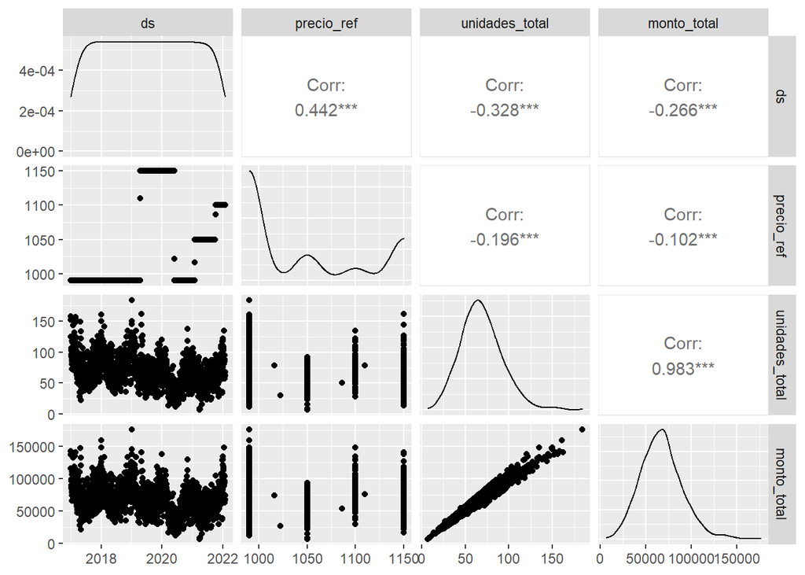

```r
GGally::ggpairs(data_train)
```

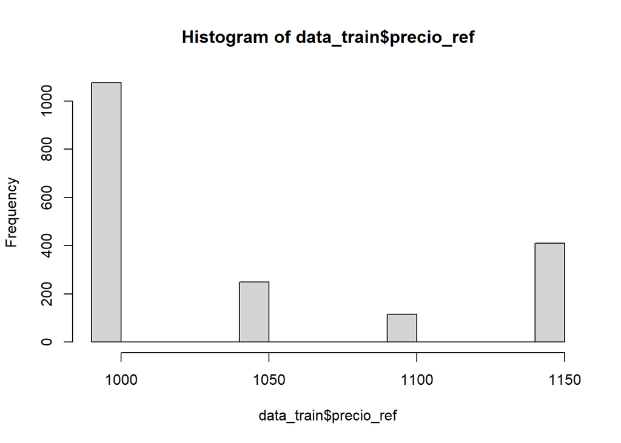

```r
hist(data_train$precio_ref)
```

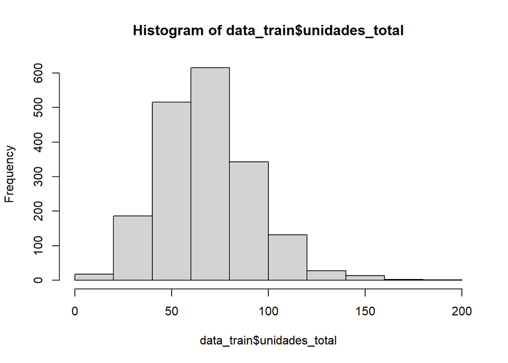

```r
hist(data_train$unidades_total)
```

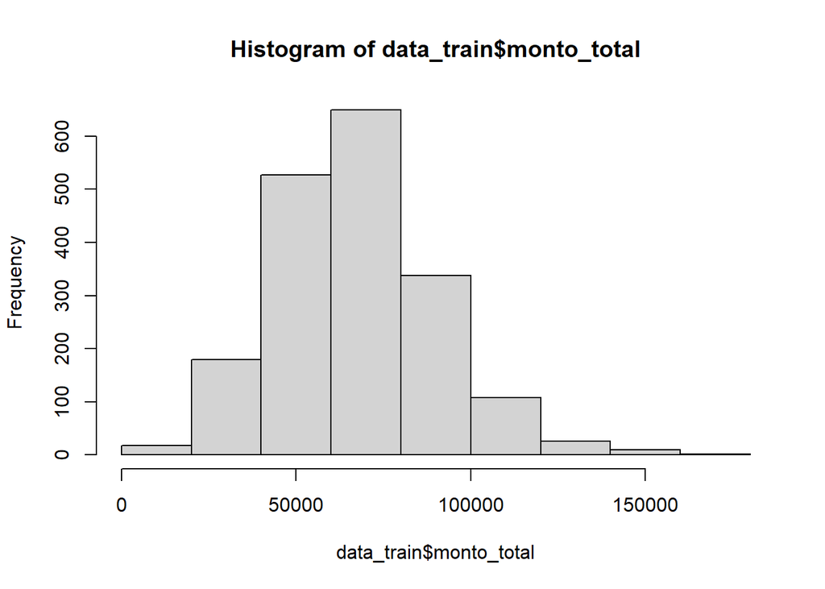

```r
hist(data_train$monto_total)
```

Dos variables parecen tener distribucion normal, y parecen tener una alta correlacion entre si, ademas parecen ser estacionarias, una de las variable como el precio no parece tener una variabilidad suficiente para ser tratada como una serie temporal.

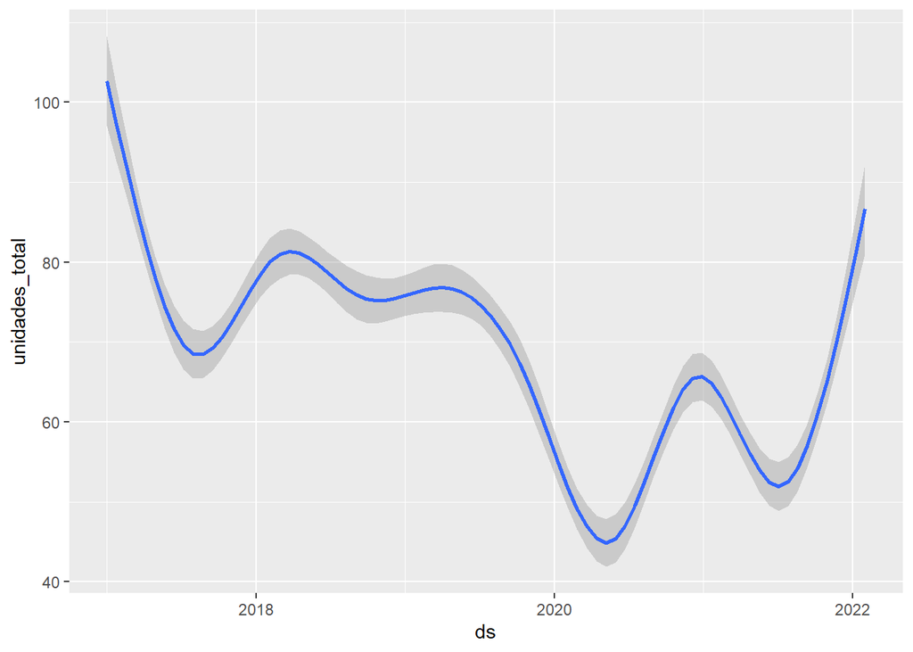

```r
data_train %>%
  ggplot(aes(ds,unidades_total)) +
  geom_smooth()
```

Utilizamos lubridate para agrupar los dias

```r
library(lubridate)
library(tidyverse)
```

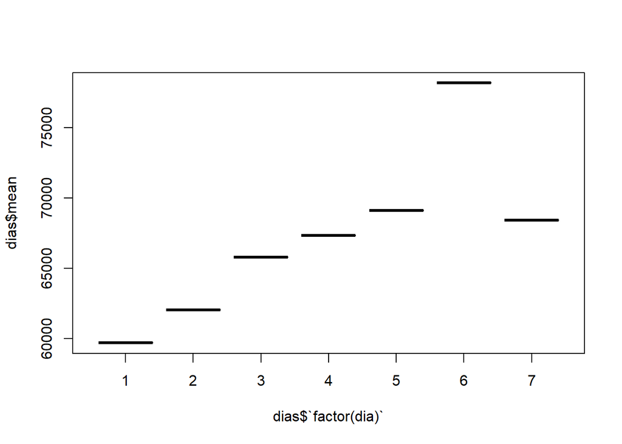

```r
data_train2 = data_train


data_train2$dia = wday(data_train2$ds)

dias =data_train2 %>%
  group_by(factor(dia)) %>%
  summarize(mean = mean(monto_total))


boxplot(dias$mean~dias$`factor(dia)`)
```

El boxplot muestras que el dia 6 de la semana tiene las mayores ventas promedio.Mientras que las ventas mas bajas parecen ser de los dias 1 y 2.

```r
#Podemos hacer una regresion lineal como variable dependiente las ventas y el dia como independiente

summary(lm(data_train2$monto_total~as.factor(data_train2$dia),data = data_train2))
```

```
##
## Call:
## lm(formula = data_train2$monto_total ~ as.factor(data_train2$dia),
##     data = data_train2)
##
## Residuals:
##    Min     1Q Median     3Q    Max
## -61685 -14147  -1033  12483 108934
##
## Coefficients:
##                             Estimate Std. Error t value Pr(>|t|)
## (Intercept)                    59696       1354  44.104  < 2e-16 ***
## as.factor(data_train2$dia)2     2346       1912   1.227  0.22004
## as.factor(data_train2$dia)3     6090       1914   3.182  0.00149 **
## as.factor(data_train2$dia)4     7643       1916   3.989 6.90e-05 ***
## as.factor(data_train2$dia)5     9412       1914   4.917 9.56e-07 ***
## as.factor(data_train2$dia)6    18474       1914   9.651  < 2e-16 ***
## as.factor(data_train2$dia)7     8723       1916   4.553 5.64e-06 ***
## ---
## Signif. codes:  0 '***' 0.001 '**' 0.01 '*' 0.05 '.' 0.1 ' ' 1
##
## Residual standard error: 22030 on 1847 degrees of freedom
## Multiple R-squared:  0.05856,    Adjusted R-squared:  0.0555
## F-statistic: 19.15 on 6 and 1847 DF,  p-value: < 2.2e-16
```

Existen relaciones estadisticamente significativas entre el dia y las ventas pero los dias explican una parte pequeña de las ventas, el ajuste del modelo es bajo 0.05.

```r
cor(data_train2$monto_total,data_train2$dia)
```

```
## [1] 0.1947814
```

Existe una correlacion debil entre el dia de la semana y las ventas.

```r
# Creamos una variable con el mes del año
data_train2$mes  = month(data_train2$ds)

data_train3 = data_train2

#Utilizamos la nueva variable que tiene el mes, para crear la epoca del año, asumiremos que son datos internacionales, asi que utilizamos las
#estaciones del año internacionales
#Invierno: diciembre - febrero = 1
#Primavera: marzo - mayo = 2
#Verano: junio - agosto = 3
#Otoño: septiembre - noviembre = 4

estaciones <- data_train3 %>%
  mutate(season =
           ifelse(mes %in% c(12, 1, 2), "1",
           ifelse(mes %in% c(3, 4, 5), "2",
           ifelse(mes %in% c(6, 7, 8), "3",
           ifelse(mes %in% c(9, 10, 11), "4", "Error")))))

#realizamos una regresion con las estaciones como variables predictoras
summary(lm(estaciones$monto_total~as.factor(estaciones$season)))
```

```
##
## Call:
## lm(formula = estaciones$monto_total ~ as.factor(estaciones$season))
##
## Residuals:
##    Min     1Q Median     3Q    Max
## -54122 -13249   -837  11766  92521
##
## Coefficients:
##                               Estimate Std. Error t value Pr(>|t|)
## (Intercept)                      83752        902   92.85   <2e-16 ***
## as.factor(estaciones$season)2   -23981       1293  -18.55   <2e-16 ***
## as.factor(estaciones$season)3   -28654       1291  -22.20   <2e-16 ***
## as.factor(estaciones$season)4   -14310       1294  -11.05   <2e-16 ***
## ---
## Signif. codes:  0 '***' 0.001 '**' 0.01 '*' 0.05 '.' 0.1 ' ' 1
##
## Residual standard error: 19800 on 1850 degrees of freedom
## Multiple R-squared:  0.2382, Adjusted R-squared:  0.237
## F-statistic: 192.9 on 3 and 1850 DF,  p-value: < 2.2e-16
```

Existe una relacion estadisticamente significativa entre las estaciones y las ventas, las estaciones explican aproximadamente el 23% en la variacion de las ventas.

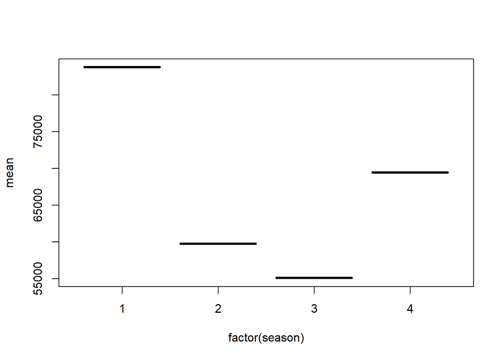

```r
estaciones1 =   estaciones %>%
  group_by(factor(season)) %>%
  summarize(mean = mean(monto_total))


plot(estaciones1)
```

En este caso el periodo que va desde diciembre a febrero parece tener la mayor cantidad de ventas promedio, mientras que entre junio y agosto existe la menor cantidad de ventas promedio.

Generamos un periodo de tiempo que abarque el inicio de la pandemia, tomando como referencia marzo del 2020

```r
estaciones3 = estaciones


pandemia =  rep(c(0,1),each=1155)
pandemia = as.data.frame(pandemia)
pandemia = pandemia[-c(1855:2310),]
pandemia = as.data.frame(pandemia)

estaciones3 = cbind(estaciones3,pandemia)
head(estaciones3)
```

```
##           ds precio_ref unidades_total monto_total dia mes season pandemia
## 1 2017-01-01        990            158      142740   1   1      1        0
## 2 2017-01-02        990            152      137180   2   1      1        0
## 3 2017-01-03        990            125      115390   3   1      1        0
## 4 2017-01-04        990            107       98710   4   1      1        0
## 5 2017-01-05        990            103       96270   5   1      1        0
## 6 2017-01-06        990             93       84808   6   1      1        0
```

```r
summary(lm(estaciones3$monto_total~as.factor(estaciones3$pandemia),data = estaciones3))
```

```
##
## Call:
## lm(formula = estaciones3$monto_total ~ as.factor(estaciones3$pandemia),
##     data = estaciones3)
##
## Residuals:
##    Min     1Q Median     3Q    Max
## -52171 -14921  -1828  13161 102702
##
## Coefficients:
##                                  Estimate Std. Error t value Pr(>|t|)
## (Intercept)                       73571.1      622.5  118.19   <2e-16 ***
## as.factor(estaciones3$pandemia)1 -16846.3     1013.8  -16.62   <2e-16 ***
## ---
## Signif. codes:  0 '***' 0.001 '**' 0.01 '*' 0.05 '.' 0.1 ' ' 1
##
## Residual standard error: 21160 on 1852 degrees of freedom
## Multiple R-squared:  0.1297, Adjusted R-squared:  0.1293
## F-statistic: 276.1 on 1 and 1852 DF,  p-value: < 2.2e-16
```

```r
cor(estaciones3$monto_total,estaciones3$pandemia)
```

```
## [1] -0.3602019
```

El periodo de inicio de tiempo de la pandemia hasta los ultimos dias de los datos, parece indicar que la pandemia afecto negativamente de forma moderada las ventas. La pandemia explico aproximadamente el 12% de la variacion de los datos en las ventas.

Si nos preguntamos si las otras variables tienen efecto en las ventas

```r
modelo<- lm(estaciones3$monto_total~estaciones3$precio_ref,data = estaciones3)
summary(modelo)
```

```
##
## Call:
## lm(formula = estaciones3$monto_total ~ estaciones3$precio_ref,
##     data = estaciones3)
##
## Residuals:
##    Min     1Q Median     3Q    Max
## -60152 -15203   -732  13661 107287
##
## Coefficients:
##                          Estimate Std. Error t value Pr(>|t|)
## (Intercept)            103630.787   8264.978  12.539  < 2e-16 ***
## estaciones3$precio_ref    -34.995      7.928  -4.414 1.07e-05 ***
## ---
## Signif. codes:  0 '***' 0.001 '**' 0.01 '*' 0.05 '.' 0.1 ' ' 1
##
## Residual standard error: 22560 on 1852 degrees of freedom
## Multiple R-squared:  0.01041,    Adjusted R-squared:  0.009878
## F-statistic: 19.49 on 1 and 1852 DF,  p-value: 1.072e-05
```

```r
cor(estaciones3$precio_ref,estaciones3$monto_total)
```

```
## [1] -0.1020407
```

Existe una relacion negativa debil entre el precio y las ventas, dicha relacion parece ser bastante debil en el modelo, el precio parece explicar el 1% de la variacion en las ventas.

Podriamos detectar los dias en que existio una promocion por el precio respectivo de los productos y sus ventas

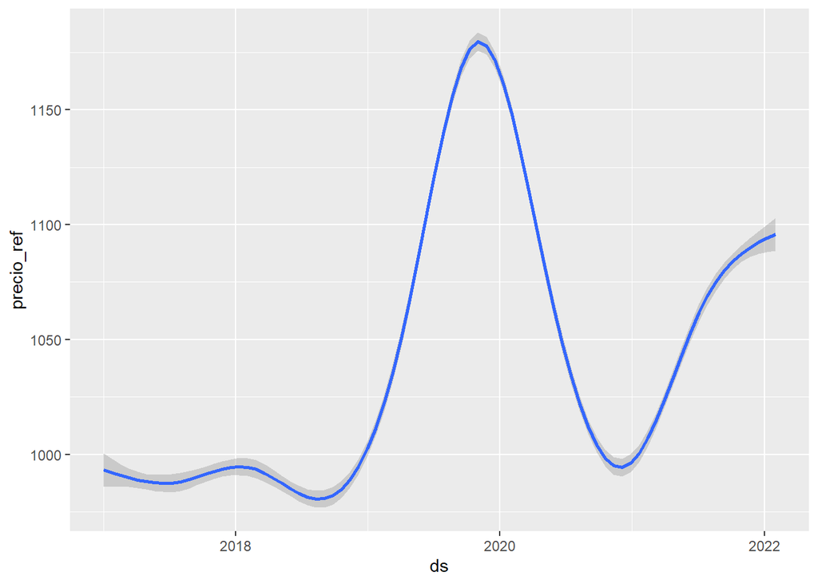

```r
estaciones3 %>%
  ggplot(aes(ds,precio_ref)) +
  geom_smooth()
```

Parecen existir diferencias en los precios segun la fecha. Para detectar ofertas podriamos detectar valores fuera de la media o agrupaciones segun el tiempo. Podriamos comparar los precios por estacion

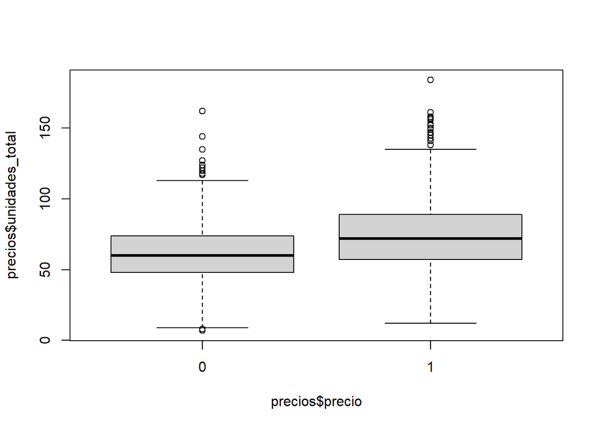

```r
#Podriamos calcular los dias en los que el precio promedio es inferior.

estaciones4 = estaciones3

 precios <-estaciones4 %>%
  group_by(dia) %>%
  mutate("precio" = precio_ref < mean(precio_ref))


precios$precio = as.numeric(precios$precio)

boxplot(precios$unidades_total~precios$precio)
```

Los dias en que los precios estan por debajo la media historica, parecen tener algunos aumentos en las unidades vendidas, con intervalos y valores atipicos.

```r
summary(lm(precios$unidades_total~precios$precio))
```

```
##
## Call:
## lm(formula = precios$unidades_total ~ precios$precio)
##
## Residuals:
##     Min      1Q  Median      3Q     Max
## -61.515 -14.515  -1.449  14.485 110.485
##
## Coefficients:
##                Estimate Std. Error t value Pr(>|t|)
## (Intercept)     61.4492     0.8305   73.99   <2e-16 ***
## precios$precio  12.0662     1.0896   11.07   <2e-16 ***
## ---
## Signif. codes:  0 '***' 0.001 '**' 0.01 '*' 0.05 '.' 0.1 ' ' 1
##
## Residual standard error: 23.15 on 1852 degrees of freedom
## Multiple R-squared:  0.0621, Adjusted R-squared:  0.06159
## F-statistic: 122.6 on 1 and 1852 DF,  p-value: < 2.2e-16
```

```r
summary(lm(precios$monto_total~precios$precio))
```

```
##
## Call:
## lm(formula = precios$monto_total ~ precios$precio)
##
## Residuals:
##    Min     1Q Median     3Q    Max
## -58382 -14822  -1160  13287 106011
##
## Coefficients:
##                Estimate Std. Error t value Pr(>|t|)
## (Intercept)     63002.9      803.4  78.424  < 2e-16 ***
## precios$precio   7259.0     1054.0   6.887 7.79e-12 ***
## ---
## Signif. codes:  0 '***' 0.001 '**' 0.01 '*' 0.05 '.' 0.1 ' ' 1
##
## Residual standard error: 22390 on 1852 degrees of freedom
## Multiple R-squared:  0.02497,    Adjusted R-squared:  0.02444
## F-statistic: 47.43 on 1 and 1852 DF,  p-value: 7.788e-12
```

Realizamos un pronostico de venta diaria

El primer paso es realizar un analisis exploratorio

Chequeamos la estacionariedad

```r
library(tseries)
```

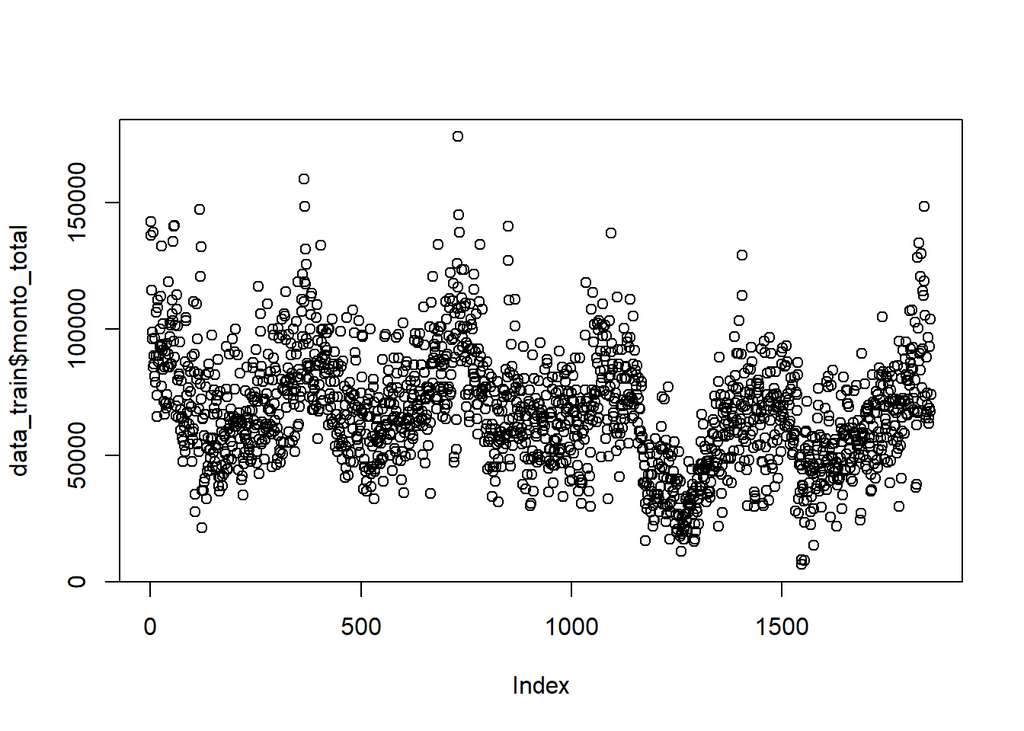

```r
plot(data_train$monto_total)
```

Realizamos un analisis con ARIMA con variables exogenas.

```r
########### Modelo VAR con variables exógenas
#Variables endógenas
#Variables endógenas
dat.VAR <- cbind(precios$precio_ref,precios$unidades_total,precios$monto_total,as.factor(precios$season),as.factor(precios$pandemia),as.factor(precios$precio))
colnames(dat.VAR) <- c("precio_ref","unidades_total","monto_total","season","pandemia","precio")


dat.EXO <- cbind(as.factor(precios$season),as.factor(precios$pandemia),as.factor(precios$precio))
colnames(dat.EXO) <- c("season","pandemia","precio")

head(dat.EXO)
```

```
##      season pandemia precio
## [1,]      1        1      2
## [2,]      1        1      2
## [3,]      1        1      2
## [4,]      1        1      2
## [5,]      1        1      2
## [6,]      1        1      2
```

```r
VAR.est <- vars::VAR(dat.VAR,lag.max=28, ic="AIC",type="const")
summary(VAR.est)
```

```
##
## VAR Estimation Results:
## =========================
## Endogenous variables: precio_ref, unidades_total, monto_total, season, pandemia, precio
## Deterministic variables: const
## Sample size: 1851
## Log Likelihood: -20171.1
## Roots of the characteristic polynomial:
## 0.9989 0.9954 0.9954 0.9877 0.9465 0.7482 0.442 0.442 0.4098 0.4098 0.3293 0.3293 0.214 0.214 0.1124 0.08974 0.08974 0.02919
## Call:
## vars::VAR(y = dat.VAR, type = "const", lag.max = 28, ic = "AIC")
##
##
## Estimation results for equation precio_ref:
## ===========================================
## precio_ref = precio_ref.l1 + unidades_total.l1 + monto_total.l1 + season.l1 + pandemia.l1 + precio.l1 + precio_ref.l2 + unidades_total.l2 + monto_total.l2 + season.l2 + pandemia.l2 + precio.l2 + precio_ref.l3 + unidades_total.l3 + monto_total.l3 + season.l3 + pandemia.l3 + precio.l3 + const
##
##                     Estimate Std. Error t value Pr(>|t|)
## precio_ref.l1      1.422e+00  4.658e-02  30.528  < 2e-16 ***
## unidades_total.l1  4.829e-02  5.173e-02   0.933  0.35073
## monto_total.l1    -4.745e-05  5.327e-05  -0.891  0.37321
## season.l1         -2.169e+00  5.514e-01  -3.933 8.72e-05 ***
## pandemia.l1       -2.322e-02  4.291e+00  -0.005  0.99568
## precio.l1          1.474e+01  4.998e+00   2.949  0.00323 **
## precio_ref.l2     -5.361e-01  6.673e-02  -8.033 1.68e-15 ***
## unidades_total.l2 -2.740e-02  5.659e-02  -0.484  0.62828
## monto_total.l2     3.361e-05  5.830e-05   0.577  0.56433
## season.l2          2.228e+00  7.803e-01   2.856  0.00434 **
## pandemia.l2        2.886e-01  6.032e+00   0.048  0.96184
## precio.l2         -1.508e+01  6.236e+00  -2.419  0.01567 *
## precio_ref.l3      1.069e-01  4.289e-02   2.493  0.01275 *
## unidades_total.l3 -2.923e-02  5.169e-02  -0.566  0.57177
## monto_total.l3     2.336e-05  5.330e-05   0.438  0.66126
## season.l3         -9.597e-02  5.573e-01  -0.172  0.86329
## pandemia.l3       -5.493e-01  4.258e+00  -0.129  0.89735
## precio.l3         -3.132e-01  4.752e+00  -0.066  0.94746
## const              8.874e+00  5.363e+00   1.654  0.09820 .
## ---
## Signif. codes:  0 '***' 0.001 '**' 0.01 '*' 0.05 '.' 0.1 ' ' 1
##
```

[output cut: 188 more lines]

```
## Correlation matrix of residuals:
##                precio_ref unidades_total monto_total     season   pandemia
## precio_ref      1.0000000       0.008631    0.014747 -2.726e-04  1.203e-02
## unidades_total  0.0086313       1.000000    0.994226  3.913e-03 -6.845e-03
## monto_total     0.0147467       0.994226    1.000000  4.846e-03 -7.763e-03
## season         -0.0002726       0.003913    0.004846  1.000e+00 -5.911e-05
## pandemia        0.0120328      -0.006845   -0.007763 -5.911e-05  1.000e+00
## precio         -0.8665908       0.005437   -0.002064  1.015e-03 -9.529e-03
##                   precio
## precio_ref     -0.866591
## unidades_total  0.005437
## monto_total    -0.002064
## season          0.001015
## pandemia       -0.009529
## precio          1.000000
```

```r
library(forecast)
(fit <- auto.arima(dat.VAR[,3],
  xreg=dat.VAR[,-3]))
```

```
## Series: dat.VAR[, 3]
## Regression with ARIMA(1,0,1) errors
##
## Coefficients:
##          ar1      ma1  precio_ref  unidades_total    season  pandemia
##       0.9691  -0.5065      4.2676        965.4136  180.0001  -129.120
## s.e.  0.0070   0.0231      1.7882          2.3587  195.1602  1031.595
##           precio
##       -2208.5236
## s.e.    702.1504
##
## sigma^2 = 3325251:  log likelihood = -16548.89
## AIC=33113.78   AICc=33113.86   BIC=33157.98
```

```r
#incluir en lo anterior en internas todas las variables

summary(fit)
```

```
## Series: dat.VAR[, 3]
## Regression with ARIMA(1,0,1) errors
##
## Coefficients:
##          ar1      ma1  precio_ref  unidades_total    season  pandemia
##       0.9691  -0.5065      4.2676        965.4136  180.0001  -129.120
## s.e.  0.0070   0.0231      1.7882          2.3587  195.1602  1031.595
##           precio
##       -2208.5236
## s.e.    702.1504
##
## sigma^2 = 3325251:  log likelihood = -16548.89
## AIC=33113.78   AICc=33113.86   BIC=33157.98
##
## Training set error measures:
##                    ME     RMSE      MAE         MPE     MAPE       MASE
## Training set 7.979888 1820.081 1201.403 -0.05625762 1.917699 0.07857132
##                    ACF1
## Training set 0.01169076
```

```r
#cargamos los datos de test que conocemos del proximo mes
library(readr)
varial <- read_delim("varial.csv", delim = ";",
    escape_double = FALSE, trim_ws = TRUE)
```

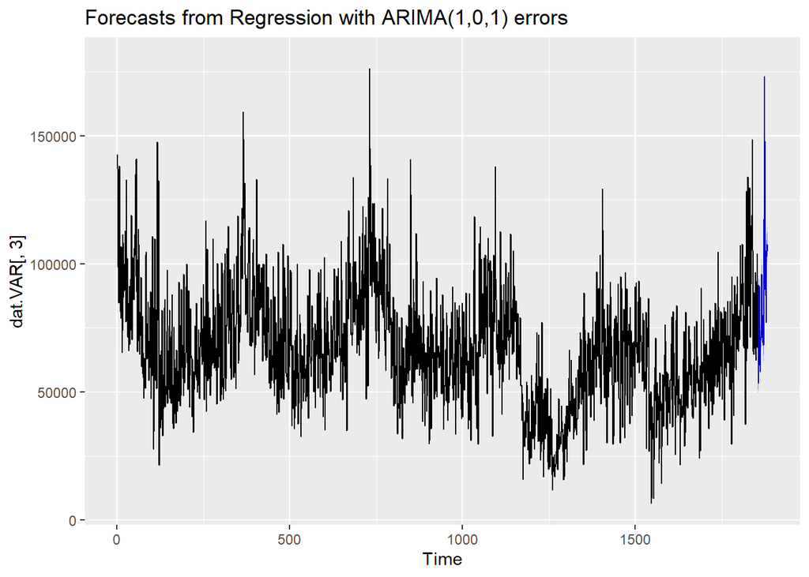

```r
varial = cbind(precio_ref=varial$precio_ref, unidades_total=varial$unidades_total,monto_total=varial$monto_total, season=varial$season,pandemia=varial$pandemia,precio=varial$precio)

#predecimos los 28 dias de febrero
 fcast <- forecast(fit, xreg=varial[,-3],h = 28)
autoplot(fcast)
```

```r
comparacion = cbind(fcast$mean,varial[,3])

mean(abs((comparacion[,2]-comparacion[,1])/comparacion[,2])) * 100
```

```
## [1] 3.302393
```

Obtenemos un error de 3.3, el modelo es bueno.

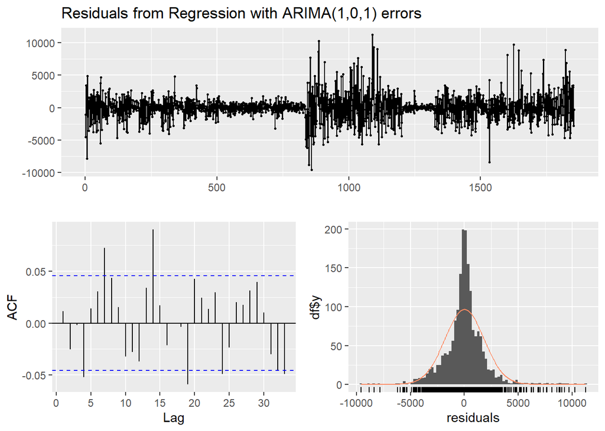

```
##
##  Ljung-Box test
##
## data:  Residuals from Regression with ARIMA(1,0,1) errors
## Q* = 24.205, df = 3, p-value = 2.264e-05
##
## Model df: 7.   Total lags used: 10
```

```r
checkresiduals(fit)
```

```r
accuracy(fcast)
```

```
##                    ME     RMSE      MAE         MPE     MAPE       MASE
## Training set 7.979888 1820.081 1201.403 -0.05625762 1.917699 0.07857132
##                    ACF1
## Training set 0.01169076
```

Para el modelo actual, el valor MAPE es 1.91. Se indica que la diferencia absoluta promedio entre el valor pronosticado y el valor original es 1.91% aproximadamente.